# TidyTuesday 2022-02-15

```r
require(tidyverse)
require(tidytuesdayR)
require(ggpubr)
tuesdata <- tidytuesdayR::tt_load('2022-02-15')
```

```r
d <- read_csv('../dubois-data-portraits/challenge/2022/challenge04/data.csv',
              col_types = cols(.default = col_double()))
d %>% glimpse()
```

[output not shown]

For this Tidy Tuesday challenge, the goal is to re-create W.E.B Du Bois’ “Valuation of Town and City Property Owned by Georgia Negroes” (plate 21) from the 1900 Paris Exposition using the tidyverse.

The first thing I did was add some columns to plot the “KKK” question marks:

```r
d <- d %>%
  mutate(val = `Property Valuation`) %>%
  mutate(KKK = case_when(
    Year < 1875 ~ val,
    Year > 1898 ~ val,
    TRUE ~ NA_real_
  )) %>%
  mutate(postKKK = case_when(
    Year >= 1874 & Year < 1899~ val,
    TRUE ~ NA_real_
  )) %>%
  mutate(KKKmark = case_when(
    is.na(KKK) ~ "",
    TRUE ~ "?"
  ))
```

Now, let’s try to get the basic shape. First, we’ll plot lines - solid black for the main values, but white for the first/last. We’ll also expand the x axis to the left so that we can build the separated y-axis. To fully separate it, I just drew a rectangle on top of the section I didn’t want to show.

```r
d %>%
  ggplot(aes(Year)) +
  geom_line(aes(y=val), size=2.5) +
  geom_line(aes(y=KKK), size=2, color='white') +
  geom_line(aes(y=postKKK), size=2) +
  geom_text(aes(y=KKK, label=KKKmark), size=1.5) +
  scale_x_continuous(breaks = seq(min(d$Year), max(d$Year), 5),
                     minor_breaks = seq(min(d$Year), max(d$Year), 1)) +
  scale_y_continuous(minor_breaks = seq(0, 4.8*1e6, 1e5),
                     breaks = c(1e6, 2*1e6, 3*1e6, 4*1e6),
                     labels = c("1,000,000", "2,000,000",
                                "3,000,000", "4,000,000")) +
  labs(x = element_blank(), y = element_blank()) +
  coord_cartesian(xlim=c(1861, 1900), ylim=c(0, 4.8*1e6), expand=FALSE) +
  theme(axis.ticks.y =element_blank()) +
  annotate('rect', xmin=1865, xmax=1870,
           ymin=0, ymax=4.8*1e6,
           fill='white')

ggsave('20220215_01.png', width=4, height=5, unit='in')
```

[output not shown]

Not bad, but now I’ll tweak that rectangle a little to clean up the edges of the plot. I’ll also add the title and force the grid to be square by setting aspect.ratio=1 within theme().

```r
d %>%
  ggplot(aes(Year)) +
  geom_line(aes(y=val), size=2.5) +
  geom_line(aes(y=KKK), size=2, color='white') +
  geom_line(aes(y=postKKK), size=2) +
  geom_text(aes(y=KKK, label=KKKmark), size=1.5) +
  scale_x_continuous(breaks = seq(min(d$Year), max(d$Year), 5),
                     minor_breaks = seq(min(d$Year), max(d$Year), 1)) +
  scale_y_continuous(minor_breaks = seq(0, 4.8*1e6, 1e5),
                     breaks = c(1e6, 2*1e6, 3*1e6, 4*1e6),
                     labels = c("1,000,000", "2,000,000",
                                "3,000,000", "4,000,000")) +
  labs(x = element_blank(), y = element_blank(),
       title="VALUATION OF TOWN AND CITY PROPERTY OWNED\nBY GEORGIA NEGROES.") +
  coord_cartesian(xlim=c(1861, 1900), ylim=c(0, 4.8*1e6), expand=FALSE) +
  theme(plot.title = element_text(hjust = 0.5, face='bold'),
        axis.ticks.y = element_blank(),
        axis.text.y = element_text(margin=margin(l=10, r=-36),
                                   size=7),
        aspect.ratio = 1) +
  annotate('rect', xmin=1865, xmax=1869.7,
           ymin=0, ymax=4.8*1e6,
           fill='white')

ggsave('20220215_02.png', width=5.1, height=5.5, unit='in')
```

[output not shown]

This is looking good! The next step is to adopt the color palette of Du Bois’ and add the horizontal major y-axis lines at every million dollars.

```r
d %>%
  ggplot(aes(Year)) +
  geom_line(aes(y=val), size=2.5) +
  geom_line(aes(y=KKK), size=2, color= "#EAE1D6") +
  geom_line(aes(y=postKKK), size=2) +
  geom_text(aes(y=KKK, label=KKKmark), size=1.5) +
  scale_x_continuous(breaks = seq(min(d$Year), max(d$Year), 5),
                     minor_breaks = seq(min(d$Year), max(d$Year), 1)) +
  scale_y_continuous(minor_breaks = seq(0, 4.8*1e6, 1e5),
                     breaks = c(1e6, 2*1e6, 3*1e6, 4*1e6),
                     labels = c("1,000,000", "2,000,000",
                                "3,000,000", "4,000,000")) +
  labs(x = element_blank(), y = element_blank(),
       title="VALUATION OF TOWN AND CITY PROPERTY OWNED\nBY GEORGIA NEGROES.") +
  coord_cartesian(xlim=c(1861, 1900), ylim=c(0, 4.9*1e6), expand=FALSE) +
  theme(plot.title = element_text(hjust = 0.5, face='bold'),
        axis.ticks.y = element_blank(),
        axis.text.y = element_text(margin=margin(l=10, r=-36),
                                   size=7),
        aspect.ratio = 1,
        panel.grid = element_line(color = "#E6A09E"),
        panel.grid.major = element_line(size=.25),
        panel.background = element_rect(fill =  "#EAE1D6"),
        plot.background = element_rect(fill =  "#EAE1D6", color =  "#EAE1D6")) +
  annotate('rect', xmin=1865, xmax=1870,
           ymin=0, ymax=4.9*1e6,
           fill="#EAE1D6") +
  geom_segment(x=1865.5, xend=1870, y=1*1e6, yend=1*1e6, color="#E6A09E", size=.25) +
  geom_segment(x=1865.5, xend=1870, y=2*1e6, yend=2*1e6, color="#E6A09E", size=.25) +
  geom_segment(x=1865.5, xend=1870, y=3*1e6, yend=3*1e6, color="#E6A09E", size=.25) +
  geom_segment(x=1865.5, xend=1870, y=4*1e6, yend=4*1e6, color="#E6A09E", size=.25) +
  annotate('rect', xmin=1861, xmax=1865, ymin=0, ymax=4.9*1e6,
           color="#131211", fill = alpha('gray', 0), size=.25) +
  annotate('rect', xmin=1870, xmax=1900, ymin=0, ymax=4.9*1e6,
           color="#131211", fill = alpha('gray', 0), size=.25)

ggsave('20220215_03.png', width=5.1, height=5.5, unit='in')
```

[output not shown]

The question marks still don’t look right. I realized that Du Bois plotted them at the midway point between the yearly data - to replicate that, I just need to find the midpoint of each line segment.

```r
d <- d %>%
  mutate(Year2 = lead(Year)) %>%
  mutate(val2 = lead(val)) %>%
  mutate(MarkX = Year + (Year2 - Year)/2) %>%
  mutate(MarkY = val + (val2 - val)/2) %>%
  mutate(MarkLabel = case_when(
    is.na(MarkX) ~ "",
    TRUE ~ "?"
  ))
```

Now when I plot the question marks they show up in the right place.

```r
d %>%
  ggplot(aes(Year)) +
  geom_line(aes(y=val), size=2.5) +
  geom_line(aes(y=KKK), size=2, color= "#EAE1D6") +
  geom_line(aes(y=postKKK), size=2) +
  geom_text(aes(x=MarkX, y=MarkY, label=MarkLabel), size=1.5) +
  scale_x_continuous(breaks = seq(min(d$Year), max(d$Year), 5),
                     minor_breaks = seq(min(d$Year), max(d$Year), 1)) +
  scale_y_continuous(minor_breaks = seq(0, 4.8*1e6, 1e5),
                     breaks = c(1e6, 2*1e6, 3*1e6, 4*1e6),
                     labels = c("1,000,000", "2,000,000",
                                "3,000,000", "4,000,000")) +
  labs(x = element_blank(), y = element_blank(),
       title="VALUATION OF TOWN AND CITY PROPERTY OWNED\nBY GEORGIA NEGROES.") +
  coord_cartesian(xlim=c(1861, 1900), ylim=c(0, 4.9*1e6), expand=FALSE) +
  theme(plot.title = element_text(hjust = 0.5, face='bold'),
        axis.ticks.y = element_blank(),
        axis.text.y = element_text(margin=margin(l=10, r=-36),
                                   size=7),
        aspect.ratio = 1,
        panel.grid = element_line(color = "#E6A09E"),
        panel.grid.major = element_line(size=.25),
        panel.background = element_rect(fill =  "#EAE1D6"),
        plot.background = element_rect(fill =  "#EAE1D6", color =  "#EAE1D6")) +
  annotate('rect', xmin=1865, xmax=1870,
           ymin=0, ymax=4.9*1e6,
           fill="#EAE1D6") +
  geom_segment(x=1865.5, xend=1870, y=1*1e6, yend=1*1e6, color="#E6A09E", size=.25) +
  geom_segment(x=1865.5, xend=1870, y=2*1e6, yend=2*1e6, color="#E6A09E", size=.25) +
  geom_segment(x=1865.5, xend=1870, y=3*1e6, yend=3*1e6, color="#E6A09E", size=.25) +
  geom_segment(x=1865.5, xend=1870, y=4*1e6, yend=4*1e6, color="#E6A09E", size=.25) +
  annotate('rect', xmin=1861, xmax=1865, ymin=0, ymax=4.9*1e6,
           color="#131211", fill = alpha('gray', 0), size=.25) +
  annotate('rect', xmin=1870, xmax=1900, ymin=0, ymax=4.9*1e6,
           color="#131211", fill = alpha('gray', 0), size=.25)

ggsave('20220215_04.png', width=5.1, height=5.5, unit='in')
```

[output not shown]

This is getting close! Now to place the text notations, including the dollar signs on the separated y-axis.

[figure not shown]

```r
d %>%
  ggplot(aes(Year)) +
  geom_line(aes(y=val), size=2.5) +
  geom_line(aes(y=KKK), size=2, color= "#EAE1D6") +
  geom_line(aes(y=postKKK), size=2) +
  geom_text(aes(x=MarkX, y=MarkY, label=MarkLabel), size=1.5) +
  scale_x_continuous(breaks = seq(min(d$Year), max(d$Year), 5),
                     minor_breaks = seq(min(d$Year), max(d$Year), 1)) +
  scale_y_continuous(minor_breaks = seq(0, 4.8*1e6, 1e5),
                     breaks = c(1e6, 2*1e6, 3*1e6, 4*1e6),
                     labels = c("1,000,000", "2,000,000",
                                "3,000,000", "4,000,000")) +
  labs(x = element_blank(), y = element_blank(),
       title="VALUATION OF TOWN AND CITY PROPERTY OWNED\nBY GEORGIA NEGROES.") +
  coord_cartesian(xlim=c(1861, 1900), ylim=c(0, 4.9*1e6), expand=FALSE) +
  theme(plot.title = element_text(hjust = 0.5, face='bold'),
        axis.ticks.y = element_blank(),
        axis.text.y = element_text(margin=margin(l=10, r=-36),
                                   size=7),
        aspect.ratio = 1,
        panel.grid = element_line(color = "#E6A09E"),
        panel.grid.major = element_line(size=.25),
        panel.background = element_rect(fill =  "#EAE1D6"),
        plot.background = element_rect(fill =  "#EAE1D6", color =  "#EAE1D6")) +
  annotate('rect', xmin=1865, xmax=1870,
           ymin=0, ymax=4.9*1e6,
           fill="#EAE1D6") +
  geom_segment(x=1865.5, xend=1870, y=1*1e6, yend=1*1e6, color="#E6A09E", size=.25) +
  geom_segment(x=1865.5, xend=1870, y=2*1e6, yend=2*1e6, color="#E6A09E", size=.25) +
  geom_segment(x=1865.5, xend=1870, y=3*1e6, yend=3*1e6, color="#E6A09E", size=.25) +
  geom_segment(x=1865.5, xend=1870, y=4*1e6, yend=4*1e6, color="#E6A09E", size=.25) +
  annotate('rect', xmin=1861, xmax=1865, ymin=0, ymax=4.9*1e6,
           color="#131211", fill = alpha('gray', 0), size=.25) +
  annotate('rect', xmin=1870, xmax=1900, ymin=0, ymax=4.9*1e6,
           color="#131211", fill = alpha('gray', 0), size=.25) +
  annotate('text', x = 1872, y=400000, label="KU-KLUXISM", size=2, angle=90) +
  annotate('text', x = 1876, y=2400000, label="POLITICAL", size=2) +
  annotate('text', x = 1877, y=2300000, label="UNREST", size=2) +
  annotate('text', x = 1891, y=1500000, label="LYNCHING", size=2) +
  annotate('text', x = 1888, y=400000, label="FINANCIAL PANIC", size=2, angle=90) +
  annotate('text', x = 1895, y=2400000, label="DISENFRANCHISMENT\nAND\nPROSCRIPTIVE\nLAWS", size=2) +
  annotate('text', x = 1880, y=4200000, label="RISE OF", size=2) +
  annotate('text', x = 1882, y=4100000, label="THE NEW", size=2) +
  annotate('text', x = 1884, y=4000000, label="INDUSTRIALISM", size=2) +
  annotate('text', x = rep(1863, 10), y=c(.4, .6, 1.4, 1.6, 2.4, 2.6, 3.4, 3.6, 4.4, 4.6)*1e6, label="$", size=2) +
  annotate('text', x = 1863, y=4.85*1e6, label='DOLLARS', size=2)


ggsave('20220215_05.png', width=5.1, height=5.5, unit='in')
```

The final tweak is to add rectangles behind the text labels to cover up the red gridlines.

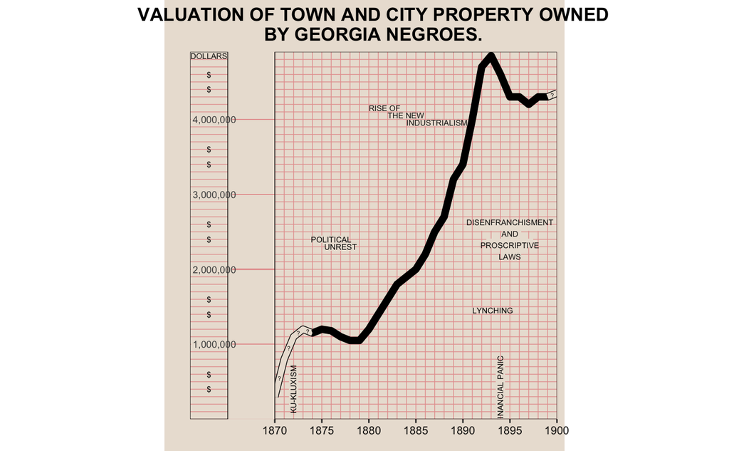

```r
d %>%
  ggplot(aes(Year)) +
  geom_line(aes(y=val), size=2.5) +
  geom_line(aes(y=KKK), size=2, color= "#EAE1D6") +
  geom_line(aes(y=postKKK), size=2) +
  geom_text(aes(x=MarkX, y=MarkY, label=MarkLabel), size=1.5) +
  scale_x_continuous(breaks = seq(min(d$Year), max(d$Year), 5),
                     minor_breaks = seq(min(d$Year), max(d$Year), 1)) +
  scale_y_continuous(minor_breaks = seq(0, 4.8*1e6, 1e5),
                     breaks = c(1e6, 2*1e6, 3*1e6, 4*1e6),
                     labels = c("1,000,000", "2,000,000",
                                "3,000,000", "4,000,000")) +
  labs(x = element_blank(), y = element_blank(),
       title="VALUATION OF TOWN AND CITY PROPERTY OWNED\nBY GEORGIA NEGROES.") +
  coord_cartesian(xlim=c(1861, 1900), ylim=c(0, 4.9*1e6), expand=FALSE) +
  theme(plot.title = element_text(hjust = 0.5, face='bold'),
        axis.ticks.y = element_blank(),
        axis.text.y = element_text(margin=margin(l=10, r=-36),
                                   size=7),
        axis.text.x = element_text(size=8, color="#131211"),
        aspect.ratio = 1,
        panel.grid = element_line(color = "#E6A09E"),
        panel.grid.major = element_line(size=.25),
        panel.background = element_rect(fill =  "#EAE1D6"),
        plot.background = element_rect(fill =  "#EAE1D6", color =  "#EAE1D6")) +
  annotate('rect', xmin=1865, xmax=1870,
           ymin=0, ymax=4.9*1e6,
           fill="#EAE1D6") +
  geom_segment(x=1865.5, xend=1870, y=1*1e6, yend=1*1e6, color="#E6A09E", size=.25) +
  geom_segment(x=1865.5, xend=1870, y=2*1e6, yend=2*1e6, color="#E6A09E", size=.25) +
  geom_segment(x=1865.5, xend=1870, y=3*1e6, yend=3*1e6, color="#E6A09E", size=.25) +
  geom_segment(x=1865.5, xend=1870, y=4*1e6, yend=4*1e6, color="#E6A09E", size=.25) +
  annotate('rect', xmin=1861, xmax=1865, ymin=0, ymax=4.9*1e6,
           color="#131211", fill = alpha('gray', 0), size=.25) +
  annotate('rect', xmin=1870, xmax=1900, ymin=0, ymax=4.9*1e6,
           color="#131211", fill = alpha('gray', 0), size=.25) +
  annotate('rect', xmin=rep(1861.1, 4), xmax=rep(1864.9, 4),
           ymin=c(.93, 1.93, 2.93, 3.93)*1e6,
           ymax=c(1.08, 2.08, 3.08, 4.08)*1e6,
           fill = "#EAE1D6", size=.25) +
  annotate('rect', xmin=1871.5, xmax=1872.5, ymin=.15*1e6, ymax=.65*1e6, fill = "#EAE1D6") +
  annotate('text', x = 1872, y=400000, label="KU-KLUXISM", size=2, angle=90) +
  annotate('rect', xmin=1874, xmax=1877.75, ymin=2.35*1e6, ymax=2.45*1e6, fill = "#EAE1D6") +
  annotate('text', x = 1876, y=2400000, label="POLITICAL", size=2) +
  annotate('rect', xmin=1875.5, xmax=1878.5, ymin=2.25*1e6, ymax=2.35*1e6, fill = "#EAE1D6") +
  annotate('text', x = 1877, y=2300000, label="UNREST", size=2) +
  annotate('rect', xmin=1890.1, xmax=1894.9, ymin=1.41*1e6, ymax=1.49*1e6, fill = "#EAE1D6") +
  annotate('text', x = 1891, y=1500000, label="LYNCHING", size=2, hjust=0, vjust=1.1) +
  annotate('rect', xmin=1893.5, xmax=1894.5, ymin=.05*1e6, ymax=.75*1e6, fill = "#EAE1D6") +
  annotate('text', x = 1894, y=400000, label="FINANCIAL PANIC", size=2, angle=90) +
  annotate('rect',
           xmin=c(1891.2, 1894.2, 1892.5, 1894.04),
           xmax=c(1898.8, 1896.2, 1897.5, 1896.2),
           ymin=c(2.51, 2.41, 2.29, 2.17)*1e6,
           ymax=c(2.63, 2.51, 2.41, 2.32)*1e6,
           fill = "#EAE1D6") +
  annotate('text', x = 1895, y=2400000, label="DISENFRANCHISMENT\nAND\nPROSCRIPTIVE\nLAWS", size=2, color="#131211") +
  annotate('rect', xmin=1880.1, xmax=1882.7, ymin=4.11*1e6, ymax=4.19*1e6, fill = "#EAE1D6") +
  annotate('text', x = 1880, y=4200000, label="RISE OF", size=2, hjust=0, vjust=1.1, color="#131211") +
  annotate('rect', xmin=1882.1, xmax=1884.7, ymin=4.01*1e6, ymax=4.09*1e6, fill = "#EAE1D6") +
  annotate('text', x = 1882, y=4100000, label="THE NEW", size=2, hjust=0, vjust=1.1, color="#131211") +
  annotate('rect', xmin=1884.1, xmax=1889.9, ymin=3.91*1e6, ymax=3.99*1e6, fill = "#EAE1D6") +
  annotate('text', x = 1884, y=4000000, label="INDUSTRIALISM", size=2, hjust=0, vjust=1.1, color="#131211") +
  annotate('text', x = rep(1863, 10), y=c(.4, .6, 1.4, 1.6, 2.4, 2.6, 3.4, 3.6, 4.4, 4.6)*1e6, label="$", size=2,  color="#131211") +
  annotate('text', x = 1863, y=4.85*1e6, label='DOLLARS', size=2, color="#131211")


ggsave('20220215_06.png', width=5.1, height=5.5, unit='in')
```